# STAT383 Final Project: Bikeshare

Toward the end of the semester, I used my DS241 skillset to do further analysis of bikeshare, this time for my final STAT383 project doing regression analysis to understand optimal bikeshare conditions in Seoul, South Korea.

The following code was all written by myself, and I feel it exemplifies my capacity to put together organized code, analyze and clean data, use various key functions in R, and produce effective visualizations.

Referencing key packages:

```r
library(tidyverse)
library(janitor)
library(here)
library(rwunderground)
```

```r
library(openmeteo)
library(ggplot2)
library(geosphere)
```

Loading raw Seoul bikeshare date (hourly):

```r
thisfile=here("data_raw", "SeoulBikeData.csv")

bikes_raw = read_csv(thisfile) %>% clean_names()
```

```r
bikes_filter = bikes_raw |>
  filter(holiday == "No Holiday", functioning_day == "Yes") |>
  select(-date, -dew_point_temperature, -solar_radiation_mj_m2, -seasons, -holiday, -functioning_day)

bikes_total = bikes_filter |>
  mutate(eql_rain_mm = rainfall_mm + snowfall_cm/10/13) |>
  select(-rainfall_mm, -snowfall_cm)

glimpse(bikes_total)
```

```
## Rows: 8,057
## Columns: 7
## $ rented_bike_count <dbl> 372, 244, 285, 226, 655, 240, 764, 639, 215, 161, 72…
## $ hour              <dbl> 0, 0, 0, 0, 0, 0, 0, 0, 0, 0, 0, 0, 0, 0, 0, 0, 0, 0…
## $ temperature_c     <dbl> 6.4, 7.1, 4.2, 4.6, 9.4, -0.4, 18.1, 11.9, 2.7, 8.5,…
## $ humidity_percent  <dbl> 84, 84, 88, 82, 85, 83, 77, 74, 73, 87, 84, 89, 60, …
## $ wind_speed_m_s    <dbl> 1.4, 2.3, 0.6, 3.0, 0.6, 1.2, 0.5, 1.6, 1.0, 0.9, 1.…
## $ visibility_10m    <dbl> 171, 185, 216, 240, 241, 247, 287, 287, 290, 303, 33…
## $ eql_rain_mm       <dbl> 0, 0, 0, 0, 0, 0, 0, 0, 0, 0, 0, 0, 0, 0, 0, 0, 0, 0…
```

Building linear regression model for ridership as a function of the following variables- hour, temperature, humidity, windspeed, visibility, and precipitation:

```r
regression_total = lm(data = bikes_total, rented_bike_count ~ hour + temperature_c + humidity_percent + wind_speed_m_s + visibility_10m + eql_rain_mm)

summary(regression_total)
```

```
##
## Call:
## lm(formula = rented_bike_count ~ hour + temperature_c + humidity_percent +
##     wind_speed_m_s + visibility_10m + eql_rain_mm, data = bikes_total)
##
## Residuals:
##      Min       1Q   Median       3Q      Max
## -1232.77  -287.90   -54.47   203.70  2300.33
##
## Coefficients:
##                   Estimate Std. Error t value Pr(>|t|)
## (Intercept)      265.77627   33.04168   8.044 9.96e-16 ***
## hour              30.04256    0.78521  38.261  < 2e-16 ***
## temperature_c     28.98659    0.43370  66.836  < 2e-16 ***
## humidity_percent  -5.38802    0.32527 -16.565  < 2e-16 ***
## wind_speed_m_s    -9.43991    5.37482  -1.756   0.0791 .
## visibility_10m     0.06537    0.01002   6.522 7.38e-11 ***
## eql_rain_mm      -63.96964    4.56719 -14.006  < 2e-16 ***
## ---
## Signif. codes:  0 '***' 0.001 '**' 0.01 '*' 0.05 '.' 0.1 ' ' 1
##
## Residual standard error: 453.4 on 8050 degrees of freedom
## Multiple R-squared:  0.5046, Adjusted R-squared:  0.5043
## F-statistic:  1367 on 6 and 8050 DF,  p-value: < 2.2e-16
```

```r
# This builds a regression model to predict total hourly ridership as with all variables as inputs, as opposed to drawing intependent trends for each variable.
```

Independent regression model for ridership vs hour of day–

Key output values: - Coefficient/slope: 40.1596 - Intercept: 277.1531 - Std Error of Slope: 0.9353 - t Value: 42.94 - Adj R Squared: 0.1862 - p Value (F statistic): < 2.2e-16 - Res Std Err: 581 on 8055 deg of freedom

```r
reg_hour = lm(data = bikes_total, rented_bike_count ~ hour)
summary(reg_hour)
```

```
##
## Call:
## lm(formula = rented_bike_count ~ hour, data = bikes_total)
##
## Residuals:
##      Min       1Q   Median       3Q      Max
## -1196.82  -395.95   -98.55   316.93  2555.97
##
## Coefficients:
##             Estimate Std. Error t value Pr(>|t|)
## (Intercept) 277.1531    12.5589   22.07   <2e-16 ***
## hour         40.1596     0.9353   42.94   <2e-16 ***
## ---
## Signif. codes:  0 '***' 0.001 '**' 0.01 '*' 0.05 '.' 0.1 ' ' 1
##
## Residual standard error: 581 on 8055 degrees of freedom
## Multiple R-squared:  0.1863, Adjusted R-squared:  0.1862
## F-statistic:  1844 on 1 and 8055 DF,  p-value: < 2.2e-16
```

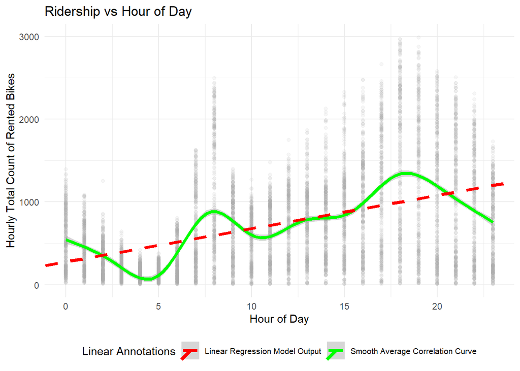

```r
hour_plot = ggplot(data = bikes_total,
                   aes(x = hour, y = rented_bike_count)) +
            geom_point(alpha = 0.1, color = "darkgrey") +
            geom_smooth(aes(color = "Smooth Average Correlation Curve"), linewidth = 1.5) +
            geom_abline(aes(intercept = 277.1531,
                        slope = 40.1596, color = "Linear Regression Model Output"),
                        linetype = "dashed",linewidth=1.5) +
            theme_minimal() +
            labs(x = "Hour of Day",
                 y = "Hourly Total Count of Rented Bikes",
                 title = "Ridership vs Hour of Day") +
  ylim(0,3000) +
  scale_color_manual(values = c("Smooth Average Correlation Curve" = "green",
                                "Linear Regression Model Output" = "red" )) +
  guides(color = guide_legend(title = "Linear Annotations")) +
  theme(legend.position = "bottom", legend.text = element_text(size = 8))

hour_plot
```

Independent regression model for ridership vs temperature–

Key output values: - Coefficient/slope: 29.4352 - Intercept: 358.7187 - Std Error of Slope: 0.4927 - t Value: 59.74 - Adj R Squared: 0.307 - p Value (F statistic): < 2.2e-16 - Res Std Err: 536.1 on 8055 deg of freedom

```r
reg_temp = lm(data = bikes_total, rented_bike_count ~ temperature_c)
summary(reg_temp)
```

```
##
## Call:
## lm(formula = rented_bike_count ~ temperature_c, data = bikes_total)
##
## Residuals:
##      Min       1Q   Median       3Q      Max
## -1075.48  -326.59   -57.18   222.39  2487.89
##
## Coefficients:
##               Estimate Std. Error t value Pr(>|t|)
## (Intercept)   358.7187     8.7322   41.08   <2e-16 ***
## temperature_c  29.4352     0.4927   59.74   <2e-16 ***
## ---
## Signif. codes:  0 '***' 0.001 '**' 0.01 '*' 0.05 '.' 0.1 ' ' 1
##
## Residual standard error: 536.1 on 8055 degrees of freedom
## Multiple R-squared:  0.3071, Adjusted R-squared:  0.307
## F-statistic:  3569 on 1 and 8055 DF,  p-value: < 2.2e-16
```

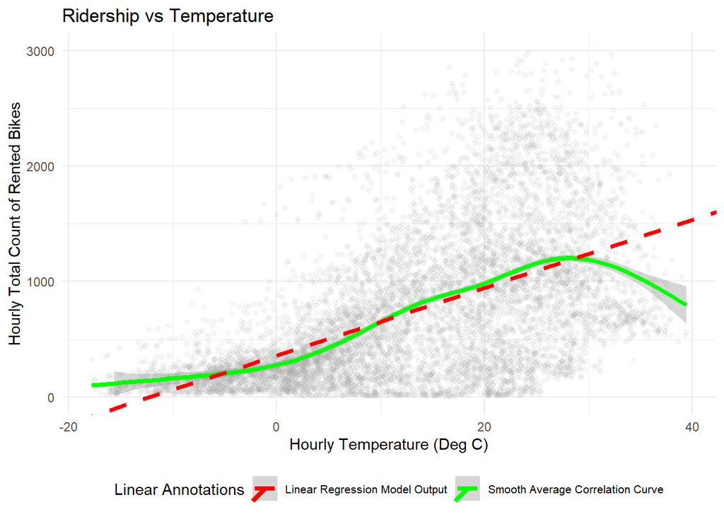

```r
temp_plot = ggplot(data = bikes_total,
                   aes(x = temperature_c, y = rented_bike_count)) +
            geom_point(alpha = 0.1, color = "darkgrey") +
            geom_smooth(aes(color = "Smooth Average Correlation Curve"), linewidth = 1.5) +
            geom_abline(aes(intercept = 358.7187,
                        slope = 29.435, color = "Linear Regression Model Output"),
                        linetype = "dashed",linewidth=1.5) +
            theme_minimal() +
            labs(x = "Hourly Temperature (Deg C)",
                 y = "Hourly Total Count of Rented Bikes",
                 title = "Ridership vs Temperature") +
  ylim(0,3000) +
  scale_color_manual(values = c("Smooth Average Correlation Curve" = "green",
                                "Linear Regression Model Output" = "red" )) +
  guides(color = guide_legend(title = "Linear Annotations")) +
  theme(legend.position = "bottom", legend.text = element_text(size = 8))

temp_plot
```

Independent regression model for ridership vs humidity–

Key output values: - Coefficient/slope: -6.7230 - Intercept: 1131.6885 - Std Error of Slope: 0.3435 - t Value: -19.57 - Adj R Squared: 0.04527 - p Value (F statistic): < 2.2e-16 - Res Std Err: 629.3 on 8055 deg of freedom

```r
reg_hum = lm(data = bikes_total, rented_bike_count ~ humidity_percent)
summary(reg_hum)
```

```
##
## Call:
## lm(formula = rented_bike_count ~ humidity_percent, data = bikes_total)
##
## Residuals:
##     Min      1Q  Median      3Q     Max
## -1018.7  -468.7  -165.9   323.1  2807.5
##
## Coefficients:
##                   Estimate Std. Error t value Pr(>|t|)
## (Intercept)      1131.6885    21.2411   53.28   <2e-16 ***
## humidity_percent   -6.7230     0.3435  -19.57   <2e-16 ***
## ---
## Signif. codes:  0 '***' 0.001 '**' 0.01 '*' 0.05 '.' 0.1 ' ' 1
##
## Residual standard error: 629.3 on 8055 degrees of freedom
## Multiple R-squared:  0.04539,    Adjusted R-squared:  0.04527
## F-statistic:   383 on 1 and 8055 DF,  p-value: < 2.2e-16
```

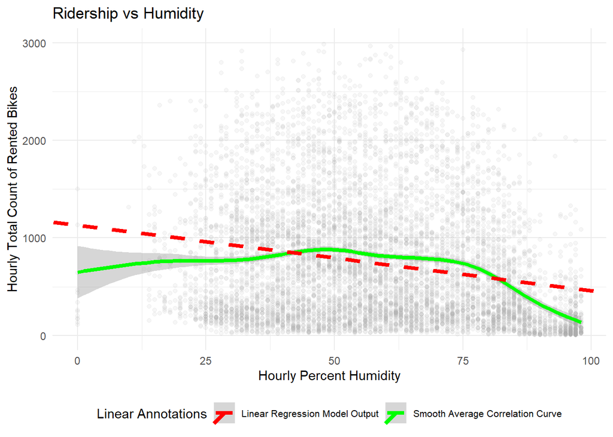

```r
hum_plot = ggplot(data = bikes_total,
                   aes(x = humidity_percent, y = rented_bike_count)) +
            geom_point(alpha = 0.1, color = "darkgrey") +
            geom_smooth(aes(color = "Smooth Average Correlation Curve"), linewidth = 1.5) +
            geom_abline(aes(intercept = 1131.6885,
                        slope = -6.7230, color = "Linear Regression Model Output"),
                        linetype = "dashed",linewidth=1.5) +
            theme_minimal() +
            labs(x = "Hourly Percent Humidity",
                 y = "Hourly Total Count of Rented Bikes",
                 title = "Ridership vs Humidity") +
  ylim(0,3000) +
  scale_color_manual(values = c("Smooth Average Correlation Curve" = "green",
                                "Linear Regression Model Output" = "red" )) +
  guides(color = guide_legend(title = "Linear Annotations")) +
  theme(legend.position = "bottom", legend.text = element_text(size = 8))

hum_plot
```

Independent regression model for ridership vs windspeed–

Key output values: - Coefficient/slope: 85.106 - Intercept: 593.025 - Std Error of Slope: 6.926 - t Value: 12.29 - Adj R Squared: 0.01828 - p Value (F statistic): < 2.2e-16 - Res Std Err: 638.1 on 8055 deg of freedom

```r
reg_wind = lm(data = bikes_total, rented_bike_count ~ wind_speed_m_s)
summary(reg_wind)
```

```
##
## Call:
## lm(formula = rented_bike_count ~ wind_speed_m_s, data = bikes_total)
##
## Residuals:
##     Min      1Q  Median      3Q     Max
## -1131.2  -495.9  -174.6   348.4  2716.2
##
## Coefficients:
##                Estimate Std. Error t value Pr(>|t|)
## (Intercept)     593.025     13.865   42.77   <2e-16 ***
## wind_speed_m_s   85.106      6.926   12.29   <2e-16 ***
## ---
## Signif. codes:  0 '***' 0.001 '**' 0.01 '*' 0.05 '.' 0.1 ' ' 1
##
## Residual standard error: 638.1 on 8055 degrees of freedom
## Multiple R-squared:  0.0184, Adjusted R-squared:  0.01828
## F-statistic:   151 on 1 and 8055 DF,  p-value: < 2.2e-16
```

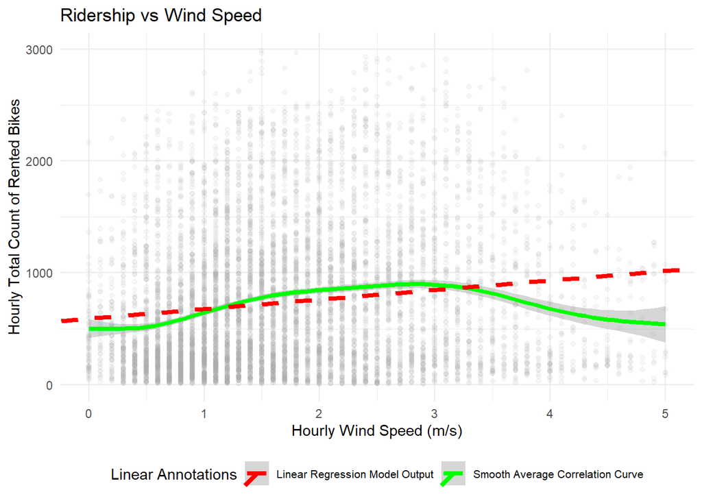

```r
wind_plot = ggplot(data = bikes_total,
                   aes(x = wind_speed_m_s, y = rented_bike_count)) +
            geom_point(alpha = 0.1, color = "darkgrey") +
            geom_smooth(aes(color = "Smooth Average Correlation Curve"), linewidth = 1.5) +
            geom_abline(aes(intercept = 593.025,
                        slope = 85.106, color = "Linear Regression Model Output"),
                        linetype = "dashed",linewidth=1.5) +
            theme_minimal() +
            labs(x = "Hourly Wind Speed (m/s)",
                 y = "Hourly Total Count of Rented Bikes",
                 title = "Ridership vs Wind Speed") +
  xlim(0,5) +
  ylim(0,3000) +
  scale_color_manual(values = c("Smooth Average Correlation Curve" = "green",
                                "Linear Regression Model Output" = "red" )) +
  guides(color = guide_legend(title = "Linear Annotations")) +
  theme(legend.position = "bottom", legend.text = element_text(size = 8))

wind_plot
```

Independent regression model for ridership vs visibility–

Key output values: - Coefficient/slope: 2.352e-02 - Intercept: 4.028e+02 - Std Error of Slope: 1.153e-03 - t Value: 20.41 - Adj R Squared: 0.04904 - p Value (F statistic): < 2.2e-16 - Res Std Err: 628 on 8055 deg of freedom

```r
bikes_total_2 = bikes_total |>
  mutate(visibility_m = visibility_10m * 10) |>
  select(-visibility_10m)

reg_vis = lm(data = bikes_total_2, rented_bike_count ~ visibility_m)
summary(reg_vis)
```

```
##
## Call:
## lm(formula = rented_bike_count ~ visibility_m, data = bikes_total_2)
##
## Residuals:
##    Min     1Q Median     3Q    Max
## -854.1 -478.0 -165.0  337.0 2847.2
##
## Coefficients:
##               Estimate Std. Error t value Pr(>|t|)
## (Intercept)  4.028e+02  1.791e+01   22.48   <2e-16 ***
## visibility_m 2.352e-02  1.153e-03   20.41   <2e-16 ***
## ---
## Signif. codes:  0 '***' 0.001 '**' 0.01 '*' 0.05 '.' 0.1 ' ' 1
##
## Residual standard error: 628 on 8055 degrees of freedom
## Multiple R-squared:  0.04916,    Adjusted R-squared:  0.04904
## F-statistic: 416.4 on 1 and 8055 DF,  p-value: < 2.2e-16
```

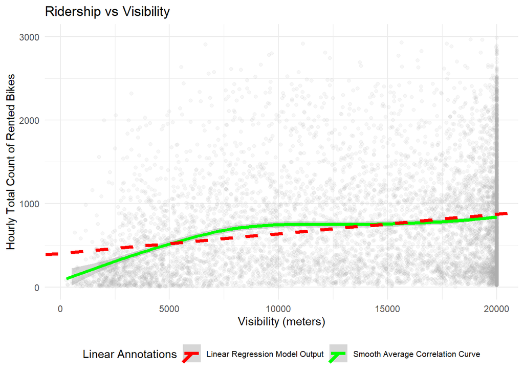

```r
vis_plot = ggplot(data = bikes_total_2,
                   aes(x = visibility_m, y = rented_bike_count)) +
            geom_point(alpha = 0.1, color = "darkgrey") +
            geom_smooth(aes(color = "Smooth Average Correlation Curve"), linewidth = 1.5) +
            geom_abline(aes(intercept = 4.028e+02,
                        slope = 2.352e-02, color = "Linear Regression Model Output"),
                        linetype = "dashed",linewidth=1.5) +
            theme_minimal() +
            labs(x = "Visibility (meters)",
                 y = "Hourly Total Count of Rented Bikes",
                 title = "Ridership vs Visibility") +
  ylim(0,3000) +
  scale_color_manual(values = c("Smooth Average Correlation Curve" = "green",
                                "Linear Regression Model Output" = "red" )) +
  guides(color = guide_legend(title = "Linear Annotations")) +
  theme(legend.position = "bottom", legend.text = element_text(size = 8))

vis_plot
```

Independent regression model for ridership vs precipitation–

Key output values: - Coefficient/slope: -73.849 - Intercept: 750.591 - Std Error of Slope: 6.213 - t Value: -11.89 - Adj R Squared: 0.01711 - p Value (F statistic): < 2.2e-16 - Res Std Err: 638.5 on 8055 deg of freedom

```r
reg_prec = lm(data = bikes_total, rented_bike_count ~ eql_rain_mm)
summary(reg_prec)
```

```
##
## Call:
## lm(formula = rented_bike_count ~ eql_rain_mm, data = bikes_total)
##
## Residuals:
##    Min     1Q Median     3Q    Max
## -746.6 -514.6 -179.6  346.4 2805.4
##
## Coefficients:
##             Estimate Std. Error t value Pr(>|t|)
## (Intercept)  750.591      7.176  104.59   <2e-16 ***
## eql_rain_mm  -73.849      6.213  -11.89   <2e-16 ***
## ---
## Signif. codes:  0 '***' 0.001 '**' 0.01 '*' 0.05 '.' 0.1 ' ' 1
##
## Residual standard error: 638.5 on 8055 degrees of freedom
## Multiple R-squared:  0.01724,    Adjusted R-squared:  0.01711
## F-statistic: 141.3 on 1 and 8055 DF,  p-value: < 2.2e-16
```

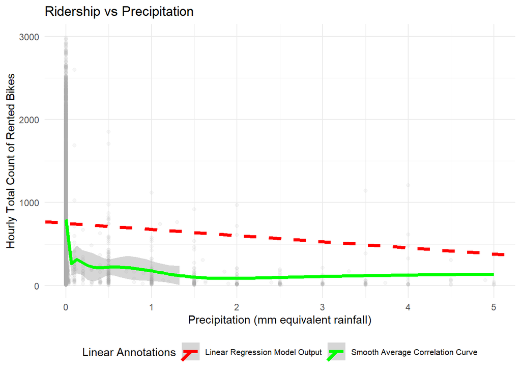

```r
prec_plot = ggplot(data = bikes_total,
                   aes(x = eql_rain_mm, y = rented_bike_count)) +
            geom_point(alpha = 0.1, color = "darkgrey") +
            geom_smooth(aes(color = "Smooth Average Correlation Curve"), linewidth = 1.5) +
            geom_abline(aes(intercept = 750.591,
                        slope = -73.849, color = "Linear Regression Model Output"),
                        linetype = "dashed",linewidth=1.5) +
            theme_minimal() +
            labs(x = "Precipitation (mm equivalent rainfall)",
                 y = "Hourly Total Count of Rented Bikes",
                 title = "Ridership vs Precipitation") +
  xlim(0,5) +
  ylim(0,3000) +
  scale_color_manual(values = c("Smooth Average Correlation Curve" = "green",
                                "Linear Regression Model Output" = "red" )) +
  guides(color = guide_legend(title = "Linear Annotations")) +
  theme(legend.position = "bottom", legend.text = element_text(size = 8))

prec_plot
```